# About Python

## Overview

## Overview

- In this lecture we will
  - Outline what Python is
  - Showcase some of its abilities
  - Compare it to some other languages

## Overview

- When we show you Python code, it is not our intention that you seek to follow all the details, or try to replicate all you see
- Our only objective for this lecture is to give you some feel of what Python is, and what it can do

## What's Python?

## What's Python?

- Python is a general purpose programming language conceived in 1989 by Dutch programmer Guido van Rossum
- Python is free and open source
- Python is supported by a vast collection of standard and external software libraries
- Python has experienced rapid adoption in the last decade, and is now one of the most popular programming languages

## What's Python?

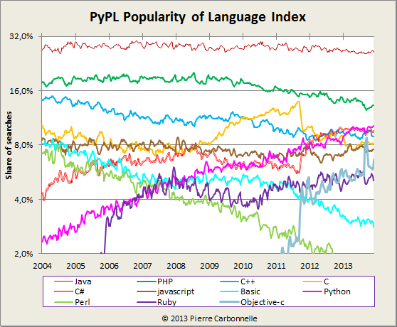

## Common Uses

- Python is a general purpose language used in almost all application domains
  - communications
  - web development
  - CGI and graphical user interfaces
  - games
  - multimedia, data processing, security, etc., etc., etc.

## Common Uses

- Used extensively by Internet service and high tech companies such as
  - Google
  - Dropbox
  - Reddit
  - YouTube
  - Walt Disney Animation, etc., etc.
- Often used to teach computer science and programming

## Common Uses

- For reasons we will discuss, Python is particularly popular within the scientific community
  - academia, NASA, CERN, etc.
  - Meteorology, computational biology, chemistry, machine learning, artificial intelligence, etc., etc.

## Features

- A high level language suitable for rapid development
- Relatively small core language supported by many libraries
- A multiparadigm language, in that multiple programming styles are supported (procedural, object-oriented, functional, etc.)
- Interpreted rather than compiled

## Syntax and Design

- One nice feature of Python is its elegant syntax.
- Elegant code might sound superfluous but in fact it's highly beneficial because it makes the syntax easy to read and easy to remember
- Closely related to elegant syntax is elegant design. Features like iterators, generators, decorators, list comprehensions, etc. make Python highly expressive, allowing you to get more done with less code.

## Scientific Programming

## Scientific Programming

- Over the last decade, Python has become one of the core languages of scientific computing
- This section briefly showcases some examples of Python for scientific programming

## Numerical programming

- Fundamental matrix and array processing capabilities are provided by the excellent NumPy library
- NumPy provides the basic array data type plus some simple processing operations

```python
import numpy as np                   # Load the library
a = np.linspace(-np.pi, np.pi, 100)  # Create array (even grid from -pi to pi)
b = np.cos(a)                        # Apply cosine to each element of a
c = np.ones(25)                      # An array of 25 ones
np.dot(c, c)                         # Compute inner product
```

## Numerical programming

- The SciPy library is built on top of NumPy and provides additional functionality
- For example, let's calculate \(\int_{-2}^2\phi(z)dz\) where \(\phi\) is the standard normal density

```python
from scipy.stats import norm
from scipy.integrate import quad
phi = norm()
value, error = quad(phi.pdf, -2, 2)  # Integrate using Gaussian quadrature
value
```

## Numerical programming

- SciPy includes many of the standard routines used in
  - linear algebra
  - integration
  - interpolation
  - optimization
  - distributions and random number generation
  - signal processing, etc., etc.

## Graphics

- The most popular and comprehensive Python library for creating figures and graphs is Matplotlib
  - Plots, histograms, contour images, 3D, bar charts, etc., etc.
  - Output in many formats (PDF, PNG, EPS, etc.)
  - LaTeX integration

## Graphics

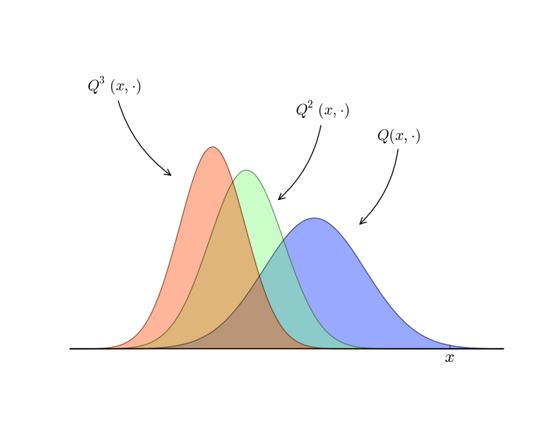

## Graphics

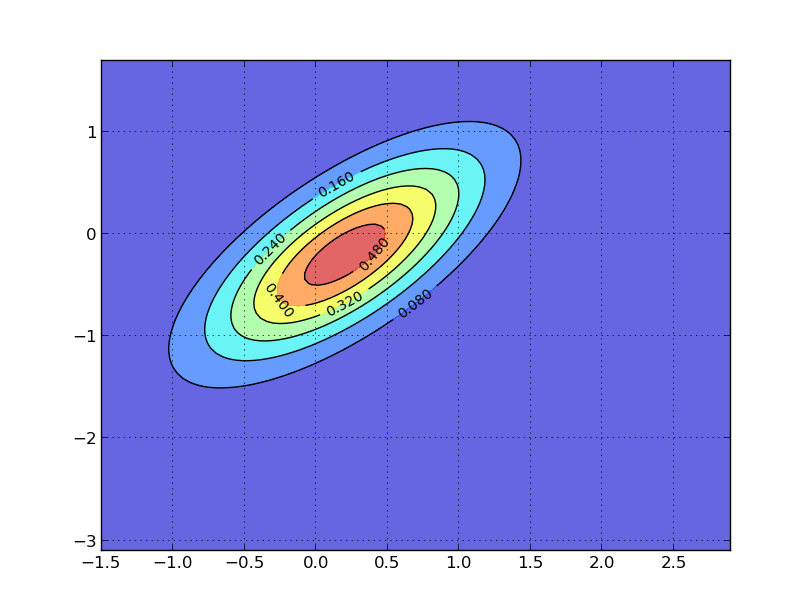

## Graphics

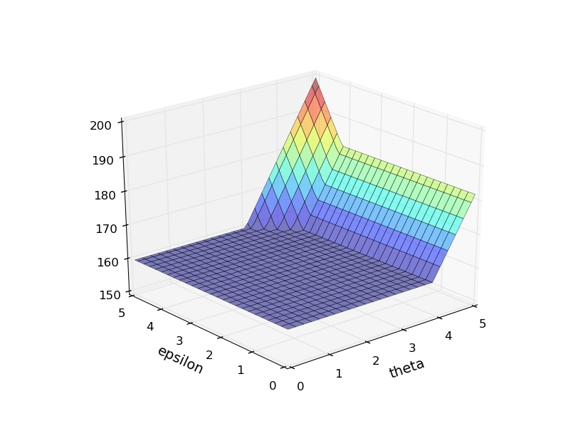

## Symbolic Algebra

- Sometimes it's useful to be able to manipulate symbolic expressions in the spirit of Mathematica/Maple
- The SymPy library provides this functionality from within the Python shell

## Symbolic Algebra

```python
from sympy import Symbol
x, y = Symbol('x'), Symbol('y')  # Treat 'x' and 'y' as algebraic symbols
x + x + x + y

expression = (x + y)**2
expression.expand()

from sympy import solve
solve(x**2 + x + 2)

from sympy import limit, sin, diff
limit(1 / x, x, 0)

limit(sin(x) / x, x, 0)

diff(sin(x), x)
```

## Statistics

- Python's data manipulation and statistics libraries have improved rapidly over the last few years
- One of the most popular libraries for working with data is pandas

## Statistics

```python
import pandas as pd
import scipy as sp
data = sp.randn(5, 2)  # Create 5x2 matrix of random numbers for toy example
dates = pd.date_range('28/12/2010', periods=5)
df = pd.DataFrame(data, columns=('price', 'weight'), index=dates)
print(df)

df.mean()
```

## Other Useful Statistics Libraries

- statsmodels - various statistical routines
- scikit-learn - machine learning in Python (sponsored by Google, among others)
- pyMC - for Bayesian data analysis
- pystan Bayesian analysis based on stan

## Other Developments

- Networks and Graphs
- Cloud Computing
- Parallel Processing, etc., etc.

## Learn More

## Learn More

- Browse some Python projects on GitHub
- Have a look at some of the IPython notebooks people have shared on various scientific topics
- Visit the Python Package Index
- View some of the question people are asking about Python on Stackoverflow